# Processing Blast Output: Taxonomy Clean Up

run date: November 21, 2023

M Fisher

written 2022-10-12

# Description

Clean up the taxonomic information for each crab (+technical replicate). This involves:

1. Removing predator DNA
2. Removing non-target bacteria, fungal DNA

Specify user directories

```r
dada_dir    <- 'data/dada2'
blast_dir   <- 'data/blast'
outdir      <- 'data/blast'
```

What are the names of the processed blast file with taxonomy from script 6?

```r
# hashes with unique staxids
blast_file <- 'lerayXT_r1-2_sample_blast_lca_taxonomy.csv'
```

What is the location / name of the metadata file for this sequencing run?

```r
run_metadat_files <- c('data/DCRB_Run1_samples.csv','data/DCRB_Run2_samples.csv')
```

And the run number and the marker

```r
run.nums <- c(1,2)
marker <- 'lerayXT'
```

# Read in data

Join the blast data to metadata information. Remove positive and negative controls (their hashes were removed in the filtering / denoising step before blasting.)

```r
blast.dat.filter <- blast.dat %>%
  dplyr::select(-tmp1) %>%
  left_join(metadat, by=c("Sample_name","Locus"="locus","MiSeqRun")) %>%
  filter(!(grepl("Control",sample_id))) %>%
  separate(sample_label, into=c("temp1","temp2","temp3"), sep="-", remove=FALSE) %>% unite(col="crab_id",c(temp1,temp2)) %>%
  mutate(sample_id=sample_label) %>%
  dplyr::select(-temp3,-sample_label)
```

Do all crab have three replicates present? *Yay! all of them.*

```r
blast.dat.filter %>% group_by(crab_id) %>% summarise(nrep=length(unique(tech))) %>% filter(nrep < 3)
```

```
## # A tibble: 0 x 2
## # ... with 2 variables: crab_id <chr>, nrep <int>
```

How many crab per site are present in the blast data?

```r
site.totals <- blast.dat.filter %>% group_by(site) %>% summarise(total_crab=length(unique(crab_id)), total_hashes=length(unique(Hash)), total_reads=sum(nReads))
site.totals %>% dplyr::select(site,total_crab)
```

```
## # A tibble: 6 x 2
##   site   total_crab
##   <chr>       <int>
## 1 CLAY           11
## 2 KAY            22
## 3 MARPT          11
## 4 PBNERR          2
## 5 SAMT            2
## 6 SIN            11
```

# Identify Taxonomy for Removal

To easier track how much data is being removed, I’m going to classify each hash as (1) to remove, and (2) reason for removal. then in the next section, I’ll filter the data and check out the prey taxa.

### Missing or Low Resolution Taxonomy

Remove any hashes that don’t have taxonomy assigned, *OR* don’t have a taxonomic rank at the order level or lower.

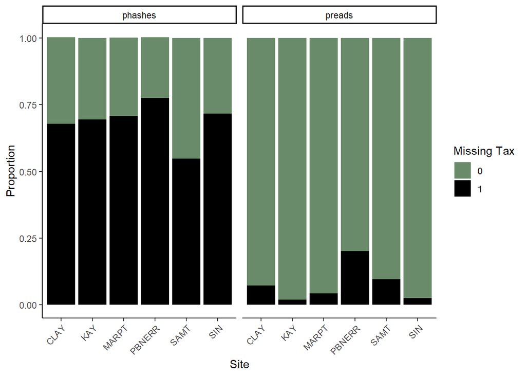

```r
blast.dat.filter %<>% mutate(missing_rm=ifelse(is.na(rank) | rank %in% c("kingdom","phylum","class"), 1,0))
```

Let’s get rid of those hashes missing taxonomy.

```r
blast.dat.filter %<>% filter(missing_rm==0)
```

calculate per crab metrics

```r
crab.totals <- blast.dat.filter %>%
  group_by(crab_id) %>% summarise(total_hashes=length(unique(Hash)), total_reads=sum(nReads))
```

### Predator DNA

Any Dungeness crab DNA will be marked as ‘predator’ DNA and removed.

- Metacarcinus magister (species)
- Metacarcinus (genus)

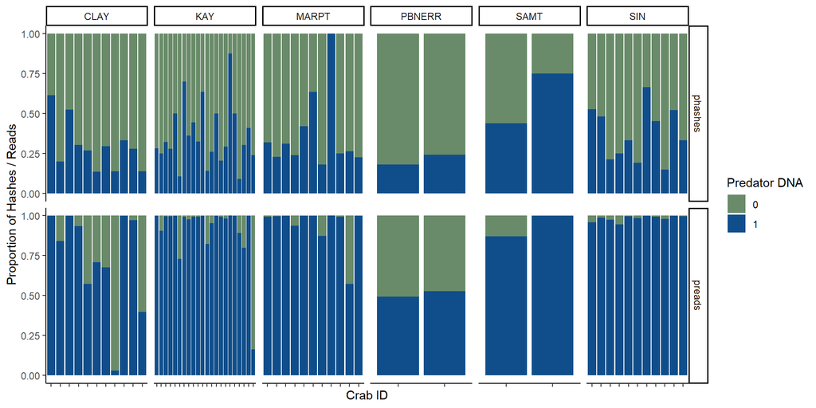

```r
blast.dat.filter %<>%
  mutate(predator_rm=ifelse(missing_rm==0 & (taxon =="Metacarcinus magister" | taxon =="Metacarcinus"), 1, 0))
```

Is there a relationships between the *total reads* in a sample, and the *proportion of predator DNA*?

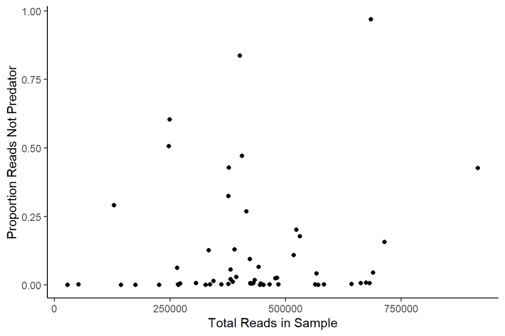

```r
blast.dat.filter %>%
  group_by(site,crab_id,predator_rm) %>%
  summarise(nreads=sum(nReads)) %>%
  left_join(crab.totals,by=c("crab_id")) %>%
  mutate(preads=nreads/total_reads) %>%
  filter(predator_rm==0) %>%
  dplyr::select(site,crab_id,preads, total_reads) %>%
  ggplot(aes(x=total_reads,y=preads), size=3, col="darkseagreen4") + geom_point() +
  labs(x="Total Reads in Sample",y="Proportion Reads Not Predator") +
  theme_classic()
```

### Bacterial, fungal etc. DNA

The data has the following phyla:

```
##  [1] "Arthropoda"      "Bacteroidota"    "Bryozoa"         "Pseudomonadota"
##  [5] "Platyhelminthes" "Bacillariophyta" "Chlorophyta"     "Annelida"
##  [9] "Discosea"        NA                "Ascomycota"      "Cnidaria"
## [13] "Mollusca"        "Basidiomycota"   "Nemertea"        "Rotifera"
## [17] "Oomycota"        "Chordata"        "Porifera"        "Nematoda"
## [21] "Echinodermata"   "Rhodophyta"      "Tubulinea"       "Foraminifera"
```

There is also one genus of amoebas (not shown above).

These are the bacterial / fungal / amoeba / unicellular algae / (human) taxa to remove:

```r
# to_remove_phyla <- c("Ascomycota","Oomycota", "Basidiomycota", #fungus
#                      "Tubulinea","Discosea", # amoeba
#                      "Bacteroidota","Proteobacteria","Pseudomonadota", # bacteria
#                      "Foraminifera") # single-celled protists
# to_remove_class <- c("Cryptophyceae")   # unicellular algae
# to_remove_genus <- c("Nannochloris","Micromonas","Pinnularia","Chattonellaceae","Chlamydomonadaceae","Chloropicaceae","Paralia","Tetraselmis")
# to_remove_taxa <- c("Primates", "Homo sapiens","Amoebozoa sp.","uncultured organism",
#                     "uncultured Jiaozhou Bay zooplankton","uncultured bacterium", "Castor canadensis")
```

```r
to_remove_phyla <- c("Ascomycota","Oomycota", "Basidiomycota", #fungus
                     "Tubulinea","Discosea", # amoeba
                     "Bacteroidota","Proteobacteria","Pseudomonadota") # bacteria
to_remove_taxa <- c("Primates", "Homo sapiens","Amoebozoa sp.","uncultured organism",
                    "uncultured Jiaozhou Bay zooplankton","uncultured bacterium", "Castor canadensis")
```

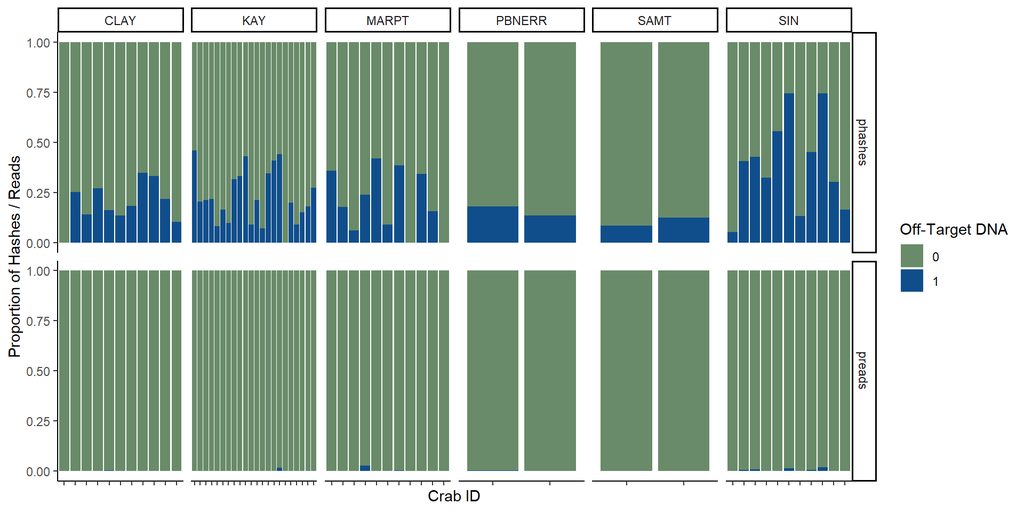

```r
blast.dat.filter %<>%
  mutate(target_rm=ifelse(phylum %in% to_remove_phyla | taxon %in% to_remove_taxa, 1, 0))
```

Great, an ok % of off-target hashes (around 20%) translates into a very low proportion of off-target reads.

# Save

## reads removed

Save a summary of the reason for removal for each Hash.

```r
write.csv(summary_dat, here(outdir, paste0(marker,"_","r",paste(run.nums,collapse="-"),"_sample_taxonomy_filtering_summary.csv")))
```

By MiSeq Run / site:

```
## You can override using the `.groups` argument.
```

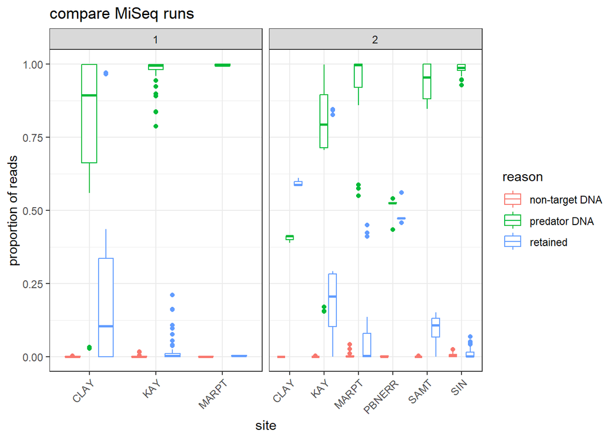

```r
blast.dat.filter %>%
  mutate(retained=ifelse(missing_rm==0 & predator_rm==0 & target_rm==0, 1,0)) %>%
  pivot_longer(cols=c(predator_rm,target_rm,retained), names_to="reason") %>%
  mutate(reason=ifelse(reason=="predator_rm","predator DNA",
                       ifelse(reason=="target_rm","non-target DNA",
                              ifelse(reason=="retained","retained",NA)))) %>%
  filter(value==1) %>%
  group_by(MiSeqRun,site,sample_id) %>%
  mutate(totalReads=sum(nReads)) %>% ungroup() %>%
  group_by(MiSeqRun,site,sample_id,reason,totalReads) %>%
  summarise(sumReads=sum(nReads)) %>% mutate(pReads=sumReads/totalReads) %>%
  ggplot(aes(x=site, y=pReads,col=reason)) + geom_boxplot() +
  facet_grid(cols=vars(MiSeqRun), scales="free_x") +
  labs(y="proportion of reads", title="compare MiSeq runs") +
  theme_bw() + theme(axis.text.x=element_text(angle=45,hjust=1))
```

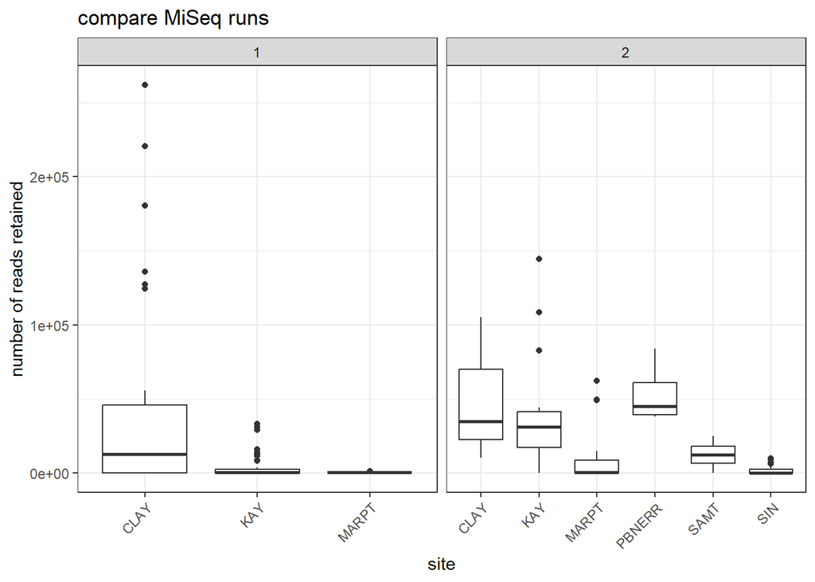

```r
blast.dat.filter %>%
  filter(missing_rm==0 & predator_rm==0 & target_rm==0) %>%
  group_by(MiSeqRun,site,sample_id) %>%
  summarise(sumReads=sum(nReads)) %>%
  ggplot(aes(x=site, y=sumReads)) + geom_boxplot() +
  facet_grid(cols=vars(MiSeqRun), scales="free_x") +
  labs(y="number of reads retained", title="compare MiSeq runs") +
  theme_bw() + theme(axis.text.x=element_text(angle=45,hjust=1))
```

check out the low-read samples in run 2:

```r
blast.dat.filter %>%
  filter(missing_rm==0 & predator_rm==0 & target_rm==0) %>%
  group_by(MiSeqRun,site,sample_id) %>%
  summarise(sumReads=sum(nReads)) %>% filter(MiSeqRun==2 & sumReads < 20)
```

```
## # A tibble: 7 x 4
## # Groups:   MiSeqRun, site [3]
##   MiSeqRun site  sample_id  sumReads
##      <dbl> <chr> <chr>         <dbl>
## 1        2 MARPT MARPT-08-a       15
## 2        2 MARPT MARPT-12-b        6
## 3        2 MARPT MARPT-12-c        5
## 4        2 SAMT  SAMT-02-c         4
## 5        2 SIN   SIN-06-a          7
## 6        2 SIN   SIN-07-c          6
## 7        2 SIN   SIN-08-c         17
```

## taxonomy

save only the remaining prey taxa.

```r
blast.dat.out <- blast.dat.filter %>%
  filter(missing_rm==0 & predator_rm==0 & target_rm==0) %>%
  dplyr::select(-"missing_rm",-"predator_rm",-"target_rm")
```

```r
write_csv(blast.dat.out, here(outdir, paste0(marker,"_","r",paste(run.nums,collapse="-"),"_sample_taxonomy_filtered.csv")))
```

Did we lose any samples?

```r
metadat[which(!(metadat$sample_label %in% blast.dat.out$sample_id)),]
```

```
## # A tibble: 24 x 7
##    Sample_name sample_label    site             crab_num tech  locus   MiSeqRun
##          <dbl> <chr>           <chr>            <chr>    <chr> <chr>      <dbl>
##  1          15 KAY-05-c        KAY              5        c     LerayXT        1
##  2          46 KAY-23-a        KAY              23       a     LerayXT        1
##  3          48 KAY-23-c        KAY              23       c     LerayXT        1
##  4          79 MARPT-14-a      MARPT            14       a     LerayXT        1
##  5          80 MARPT-14-b      MARPT            14       b     LerayXT        1
##  6          81 MARPT-14-c      MARPT            14       c     LerayXT        1
##  7          95 PositiveControl Positive Control <NA>     <NA>  LerayXT        1
##  8          96 NegativeControl Negative Control <NA>     <NA>  LerayXT        1
##  9          10 MARPT-12-a      MARPT            12       a     LerayXT        2
## 10          25 MARPT-14-a      MARPT            14       a     LerayXT        2
## # ... with 14 more rows
```

How many crab per site are present in the filtered blast data?

```r
site.totals <- blast.dat.out %>% group_by(site) %>% summarise(total_crab=length(unique(crab_id)), total_hashes=length(unique(Hash)), total_reads=sum(nReads))
site.totals %>% dplyr::select(site,total_crab)
```

```
## # A tibble: 6 x 2
##   site   total_crab
##   <chr>       <int>
## 1 CLAY           11
## 2 KAY            22
## 3 MARPT          10
## 4 PBNERR          2
## 5 SAMT            2
## 6 SIN            11
```

## unique taxa

```r
dat.out <- read_csv(here(outdir, paste0(marker,"_","r",paste(run.nums,collapse="-"),"_sample_taxonomy_filtered.csv")))
```

save just the species-level IDs

```r
spdat <- dat.out %>% filter(rank=="species")


spdat_summary <- spdat %>% group_by(taxon,kingdom,phylum,class,order,family,genus,species) %>%
  summarise(n.crab=length(unique(crab_id)),
            n.sites=length(unique(site)),
            sites=paste(site,collapse=", "))
```

```
## 'order', 'family', 'genus'. You can override using the `.groups` argument.
```

```r
write_csv(spdat, (here(outdir, paste0(marker,"_","r",paste(run.nums,collapse="-"),"_sample_taxonomy_filtered_species.csv"))))
write_csv(spdat_summary, (here(outdir, paste0(marker,"_","r",paste(run.nums,collapse="-"),"_sample_taxonomy_filtered_speciesSUMMARY.csv"))))
```

keep non-specific ids in data set *only if that taxon is not represented for the given crab in the species-level data* – for all plant / algae IDs allow for order thru genus, otherwise just through genus

```r
nonspec_dat <- dat.out %>%
  filter((phylum %in% c("Chlorophyta","Rhodophyta","Streptophyta") & rank=="order") | (class %in% c("Phaeophyceae") & rank=="order") | rank %in% c("genus","family")) %>%
  mutate(dup_sample=crab_id)

nonspec_dat %<>%
  group_by(crab_id) %>%
  nest()

nonspec_dat %<>% mutate(data.filter=purrr::map(data,remove_duplicate_taxonomy_algae, sp.dat=spdat))

unqdat <- nonspec_dat %>% dplyr::select(-data) %>% unnest(c(crab_id,data.filter)) %>% dplyr::select(-dup_sample) %>%
  bind_rows(spdat)
```

manually remove duplicates that have two + entries of higher level taxonomy.

```r
duplicates_to_edit <- unqdat %>%
  filter(rank!="species") %>%
  dplyr::select(crab_id,Hash,taxon,rank,species,genus,family,order,class) %>% distinct() %>%
  group_by(Hash, crab_id) %>% summarise(duplicated.ranks=length(unique(rank))) %>% filter(duplicated.ranks > 1)
duplicates_to_edit
```

```
## # A tibble: 6 x 3
## # Groups:   Hash [6]
##   Hash                                     crab_id  duplicated.ranks
##   <chr>                                    <chr>               <int>
## 1 1190ea6a61d23f996ab852bf67978413355a6b53 SAMT_01                 2
## 2 4b6c8c35716974f06be0f76c7de6843794dc1b73 CLAY_13                 2
## 3 5434d354d98463a68a0e753c78525f1f892ec06d KAY_25                  2
## 4 a67e6e12eb3f3b86509f15407feb68237b2c5f83 MARPT_16                2
## 5 b794dcd132dede4484b9f61bb7e3810d1b42b5b4 MARPT_16                2
## 6 d6c968ea8f9865b7706218a113d9f92851824e7b SIN_03                  2
```

```r
# View(left_join(duplicates_to_edit, unqdat))  ## 6 hashes with duplicated ranks
```

```r
# fix hashes
tmpdat <- filter(unqdat, Hash=="1190ea6a61d23f996ab852bf67978413355a6b53" & crab_id %in% c("SAMT_01")) %>%
  filter(rank=="genus") %>%
  bind_rows(
    filter(unqdat, Hash=="4b6c8c35716974f06be0f76c7de6843794dc1b73" & crab_id %in% c("CLAY_13")) %>%
  filter(rank=="family")
  ) %>%
  bind_rows(
    filter(unqdat, Hash=="5434d354d98463a68a0e753c78525f1f892ec06d" & crab_id %in% c("KAY_25")) %>%
  filter(rank=="genus")
  ) %>%
  bind_rows(
    filter(unqdat, Hash=="a67e6e12eb3f3b86509f15407feb68237b2c5f83" & crab_id %in% c("MARPT_16")) %>%
  filter(rank=="genus")
  ) %>%
  bind_rows(
    filter(unqdat, Hash=="b794dcd132dede4484b9f61bb7e3810d1b42b5b4" & crab_id %in% c("MARPT_16")) %>%
  filter(rank=="genus")
  ) %>%
  bind_rows(
    filter(unqdat, Hash=="d6c968ea8f9865b7706218a113d9f92851824e7b" & crab_id %in% c("SIN_03")) %>%
  filter(rank=="genus")
  )


unqdat %<>% anti_join(dplyr::select(duplicates_to_edit, c(Hash,crab_id))) %>%
  bind_rows(tmpdat)
```

Save

```r
write_csv(unqdat, (here(outdir, paste0(marker,"_","r",paste(run.nums,collapse="-"),"_sample_taxonomy_filtered_uniqueTaxa.csv"))))


unqdat %>%
  group_by(taxon,rank,kingdom,phylum,class,order,family,genus,species) %>%
  summarise(n.crab=length(unique(crab_id)),
            n.sites=length(unique(site)),
            sites=paste0(unique(site),collapse=","),
            miseqruns=paste0(unique(MiSeqRun),collapse=",")) %>%
write_csv((here(outdir, paste0(marker,"_","r",paste(run.nums,collapse="-"),"_sample_taxonomy_filtered_uniqueTaxaSUMMARY.csv"))))
```

# Manual filter

```r
unqdat <- read_csv((here(outdir, paste0(marker,"_","r",paste(run.nums,collapse="-"),"_sample_taxonomy_filtered_uniqueTaxa.csv"))))
```

## update dataset

After manually checking taxon identifications against databases, I want to filter out the potential mis-identifications and missed non-target IDs.

```r
manual_filter <- readxl::read_excel(path=here('data','results','lerayXT_r1-2_sample_taxonomy_filtered_uniqueTaxaSUMMARY.xlsx'),sheet='lerayXT_r1-2_final')
head(manual_filter)
```

```
## # A tibble: 6 x 6
##   taxon                     rank    group       removal_code new_taxon   new_r~1
##   <chr>                     <chr>   <chr>       <chr>        <chr>       <chr>
## 1 Monocorophium acherusicum species amphipod    <NA>         Monocoroph~ species
## 2 Chordariaceae             family  brown algae <NA>         Chordariac~ family
## 3 Euchlanis dilatata        species rotifer     <NA>         Euchlanis ~ species
## 4 Balanus crenatus          species barnacle    <NA>         Balanus cr~ species
## 5 Pleurosigma               genus   diatom      <NA>         Pleurosigma genus
## 6 Hormosira banksii         species brown algae <NA>         Fucales     order
## # ... with abbreviated variable name 1: new_rank
```

```r
filter(manual_filter, !is.na(removal_code)) %>% pull(removal_code)
```

```
## [1] "insect contaminant"             "parasite"
## [3] "insect contaminant"             "parasite; outside distribution"
## [5] "outside distribution"
```

Add unicellular organisms to the manual filter.

```r
too_small_dat <- unqdat %>% filter(phylum %in% c("Bacillariophyta","Rotifera", "Foraminifera") |
                            class %in% c("Dinophyceae","Chlorophyceae", "Raphidophyceae","Cryptophyceae",
                                         "Eustigmatophyceae","Pelagophyceae","Mamiellophyceae"))
too_small_filter <- dplyr::select(too_small_dat, taxon, rank) %>%
  distinct() %>%
  left_join(manual_filter) %>%
  mutate(removal_code=ifelse(is.na(removal_code),"too small",removal_code))
manual_filter %<>% filter(!(taxon %in% too_small_filter$taxon)) %>%
  bind_rows(too_small_filter) %>% distinct()
```

Join the dataframe to the unique taxa dataset, and filter out taxa. Also get rid of some un-needed columns.

```r
unqdat_filter <- unqdat %>%
  dplyr::select(-c(19:36)) %>%
  left_join(manual_filter, by=c("taxon","rank")) %>%
  filter(is.na(removal_code))
```

Rename taxa if needed (usually to back out species to genus, if the species name is just a sample identifier from blast, or if the species is not known to be found in the Puget Sound but the genus is.)

```r
unqdat_filter <- unqdat_filter %>% filter(rank!=new_rank | taxon!=new_taxon) %>%
  mutate(taxon=new_taxon,
         rank=new_rank) %>%
  bind_rows(filter(unqdat_filter,rank==new_rank))

## check some of the renamed taxa
head(filter(unqdat_filter,rank=="genus" & !is.na(species)) %>% dplyr::select(crab_id,sample_id,MiSeqRun,rank,taxon,species))
```

```
## # A tibble: 6 x 6
##   crab_id sample_id MiSeqRun rank  taxon       species
##   <chr>   <chr>        <dbl> <chr> <chr>       <chr>
## 1 KAY_02  KAY-02-b         1 genus Scytosiphon Scytosiphon sp. Mitopromiscuus
## 2 KAY_21  KAY-21-b         1 genus Paracalanus Paracalanus sp. C AC-2013
## 3 CLAY_02 CLAY-02-a        1 genus Scopalina   Scopalina ruetzleri
## 4 CLAY_02 CLAY-02-c        1 genus Scopalina   Scopalina ruetzleri
## 5 CLAY_03 CLAY-03-a        1 genus Platynereis Platynereis sp. CMC02
## 6 CLAY_07 CLAY-07-b        1 genus Ectocarpus  Ectocarpus crouaniorum
```

## remove duplicate IDs

Repeat the process above, where duplicate taxonomic identifications per crab are removed (because of a species/genus combination or similar)

First, grab species-level IDs

```r
# species-level IDs
spdat <- unqdat_filter %>% filter(rank=="species")

spdat_summary <- spdat %>% group_by(taxon,kingdom,phylum,class,order,family,genus,species) %>%
  summarise(n.crab=length(unique(crab_id)),
            n.sites=length(unique(site)),
            sites=paste(site,collapse=", "))
```

```
## 'order', 'family', 'genus'. You can override using the `.groups` argument.
```

```r
write_csv(spdat_summary, (here('data','results', paste0(marker,"_","r",paste(run.nums,collapse="-"),"_sample_taxonomy_filtered2_speciesSUMMARY.csv"))))
```

keep non-specific ids in data set *only if that taxon is not represented for the given crab in the species-level data*

```r
nonspec_dat <- unqdat_filter %>%
  filter(rank != "species") %>%
  mutate(dup_sample=crab_id)

nonspec_dat %<>%
  group_by(crab_id) %>%
  nest()
#
# remove_duplicate_taxonomy <- function(x){
#   tmp_sample <- as.character(unique(x[,"dup_sample"]))
#
#   if(tmp_sample %in% spdat$crab_id){
#     x.filter <- x %>%
#       filter(!(taxon %in% (filter(spdat,crab_id==tmp_sample))$genus) & !(taxon %in% (filter(spdat,crab_id==tmp_sample))$family) & !(taxon %in% (filter(spdat,crab_id==tmp_sample))$order))
#     return(x.filter)
#
#   } else{return(x)}
# }

nonspec_dat %<>% mutate(data.filter=purrr::map(data,remove_duplicate_taxonomy, sp.dat=spdat))

unqdat_filter2 <- nonspec_dat %>% dplyr::select(-data) %>% unnest(c(crab_id,data.filter)) %>% dplyr::select(-dup_sample) %>%
  bind_rows(spdat)
```

Save the final filtered taxonomy

```r
write_csv(unqdat_filter2, (here('data','results', paste0(marker,"_","r",paste(run.nums,collapse="-"),"_sample_taxonomy_filtered2_uniqueTaxa.csv"))))
```

Save a summary of the final filtered taxonomy

```r
unq_filter2_summary <- unqdat_filter2 %>%
  group_by(taxon,rank,kingdom,phylum,class,order,family,genus,species) %>%
  summarise(n.crab=length(unique(crab_id)),
            n.sites=length(unique(site)),
            sites=paste0(unique(site),collapse=","),
            miseqruns=paste0(unique(MiSeqRun),collapse=","))
```

```
## 'class', 'order', 'family', 'genus'. You can override using the `.groups`
## argument.
```

```r
write_csv(unq_filter2_summary, (here('data','results', paste0(marker,"_","r",paste(run.nums,collapse="-"),"_sample_taxonomy_filtered2_uniqueTaxaSUMMARY.csv"))))
```

## “too small” dataset

I want to create a “rotifers / microalgae / protists” category that could potentially represent ingestion of detritus; Galloway et al. included detritus in their feeding experiments for Dungeness crab instars. This does *not* include fungi, amoebas, or bacteria

**First, lines 424 to 454 above if needed**.

Then, grab the ‘too small’ items from the edited manual filter.

```r
unqdat.small <- unqdat %>%
  dplyr::select(-c(19:36)) %>%
  filter(taxon %in% filter(manual_filter,removal_code=="too small")$taxon) %>%
  left_join(manual_filter)
# rename as needed
unqdat.small %<>% mutate(taxon=new_taxon,rank=new_rank) %>% dplyr::select(-new_taxon,-new_rank)
```

First, grab species-level IDs

```r
# species-level IDs
spdat.sm <- unqdat.small %>% filter(rank=="species")

spdat.sm_summary <- spdat.sm %>% group_by(taxon,kingdom,phylum,class,order,family,genus,species) %>%
  summarise(n.crab=length(unique(crab_id)),
            n.sites=length(unique(site)),
            sites=paste(site,collapse=", "))
```

```
## 'order', 'family', 'genus'. You can override using the `.groups` argument.
```

```r
write_csv(spdat.sm_summary, (here('data','results', paste0(marker,"_","r",paste(run.nums,collapse="-"),"_sample_taxonomy_filtered2_SmallTaxa_speciesSUMMARY.csv"))))
```

clean up non-unique taxa within each crab

```r
# IDs above species-level
nonspec_dat_small <- unqdat.small %>%
  filter(rank != "species") %>%
  mutate(dup_sample=crab_id)

nonspec_dat_small %<>%
  group_by(crab_id) %>%
  nest()

nonspec_dat_small %<>% mutate(data.filter=purrr::map(data,remove_duplicate_taxonomy, spdat.sm))

small.out <- nonspec_dat_small %>% dplyr::select(-data) %>% unnest(c(crab_id,data.filter)) %>% dplyr::select(-dup_sample) %>%
  bind_rows(spdat.sm)
```

Save!

```r
write_csv(small.out, (here('data','results', paste0(marker,"_","r",paste(run.nums,collapse="-"),"_sample_taxonomy_filtered2_SmallTaxa_uniqueTaxa.csv"))))
```

Save a summary of the final filtered taxonomy

```r
unq_filter2_small_summary <- small.out %>%
  group_by(taxon,rank,kingdom,phylum,class,order,family,genus,species) %>%
  summarise(n.crab=length(unique(crab_id)),
            n.sites=length(unique(site)),
            sites=paste0(unique(site),collapse=","),
            miseqruns=paste0(unique(MiSeqRun),collapse=",")) %>%
write_csv((here('data','results', paste0(marker,"_","r",paste(run.nums,collapse="-"),"_sample_taxonomy_filtered2_SmallTaxa_uniqueTaxaSUMMARY.csv"))))
```